# Recognition voting 2017

## Dinner tastes victory in close vote

#### **Voters not yet Board of Jack Straws, but no Room for Escape in reckoning**

Turnout was 75% (24/32); all but two ballots were filled out fully. The vote was very even, with five of the six options receiving at least four first preference votes; the exception being Escape the Room, which we did last year.

The vote in full (ballot numbers randomised):

```
##     Dinner Bowling Avoca Board Escape Laser
## b16      1       2     5     4      6     3
## b20      1       2     5     4      6     3
## b13      1       3     2     4      5     6
## b18      1       3     6     5      2     4
## b4       1       6     4     2      3     5
## b7       1       6     3     2      6     6
## b8       2       1     6     5      3     4
## b1       2       5     1     3      6     4
## b10      2       5     4     1      3     6
## b14      2       5     4     1      3     6
## b9       2       6     1     5      4     3
## b15      2       6     1     3      5     4
## b2       3       2     6     5      4     1
## b11      4       1     5     2      3     6
## b19      4       1     6     2      3     5
## b21      4       1     3     5      6     2
## b12      4       2     1     3      5     6
## b17      5       2     6     4      3     1
## b24      5       3     6     4      2     1
## b23      5       4     6     2      3     1
## b5       6       2     1     3      5     4
## b6       6       2     1     5      4     3
## b3       6       4     5     1      2     3
## b22      6       6     2     1      6     3
```

There were two pairs of identical ballots: 16 and 20, and 10 and 14.

Bowling, Board and Laser tied on 4 first preference votes, creating a tie that is resolved randomly by the STV algorithm, requiring an ensemble of runs to determine the true winner. There are three possible winners, occurring (from 10,000 iterations) at frequencies:

```
##   candidate elected_pct
## 1    Dinner       50.01
## 3   Bowling       33.16
## 2     Board       16.83
```

This split occurs due to the three-way tie in the first round and a final-round tie in one of the pathways. Check out these fancy tables below (made using `formattable` and `kableExtra`) showing the counts. The quota is 13.

**Pathway 1:** Board eliminated first; **Dinner** gets strong transfers from Bowling and Laser and wins comfortably from Avoca.

| Candidate | Round_1 | Round_2 | Round_3 | Round_4 | Round_5 | Elected |
| --- | --- | --- | --- | --- | --- | --- |
| Dinner | 6 | 6 | 8 | 11 | 15 |  |
| Avoca | 6 | 6 | 7 | 7 | 9 |  |
| Laser | 4 | 4 | 5 | 6 |  |  |
| Bowling | 4 | 4 | 4 |  |  |  |
| Board | 4 | 4 |  |  |  |  |
| Escape | 0 |  |  |  |  |  |

**Pathway 2:** Laser eliminated first and transfers strongly to Bowling; one incomplete vote is dropped after Avoca is eliminated; **Bowling** edges it from Dinner. Stronger transfers from Avoca to Dinner might have been expected here.

| Candidate | Round_1 | Round_2 | Round_3 | Round_4 | Round_5 | Round_6 | Elected |
| --- | --- | --- | --- | --- | --- | --- | --- |
| Dinner | 6 | 6 | 6 | 8 | 11 |  |  |
| Avoca | 6 | 6 | 6 | 7 |  |  |  |
| Bowling | 4 | 4 | 7 | 9 | 12 | 22 |  |
| Board | 4 | 4 | 5 |  |  |  |  |
| Laser | 4 | 4 |  |  |  |  |  |
| Escape | 0 |  |  |  |  |  |  |

**Pathway 3:** Bowling eliminated first; **Board** takes enough transfers from the rest to catch Dinner and win in a tie.

| Candidate | Round_1 | Round_2 | Round_3 | Round_4 | Round_5 | Round_6 | Elected |
| --- | --- | --- | --- | --- | --- | --- | --- |
| Dinner | 6 | 6 | 7 | 8 | 12 |  |  |
| Avoca | 6 | 6 | 6 | 7 |  |  |  |
| Board | 4 | 4 | 6 | 9 | 12 | 24 |  |
| Laser | 4 | 4 | 5 |  |  |  |  |
| Bowling | 4 | 4 |  |  |  |  |  |
| Escape | 0 |  |  |  |  |  |  |

**Pathway 4:** As Pathway 3, but **Dinner** wins on the tie. Arguably Dinner could always win this tie due to its greater first preferences.

Dinner wins more often, and is only beaten by narrow margins, so is the strongest candidate overall.

This is backed up by looking at the candidates’ total first preferences (red), and their overall popularity by two methods; one assigning 5,4…0 points for preferences 1,2…6 (green), and the other weighting preference 1 twice as strongly as preference 2, four times as strongly as preference 3, and so on (blue).

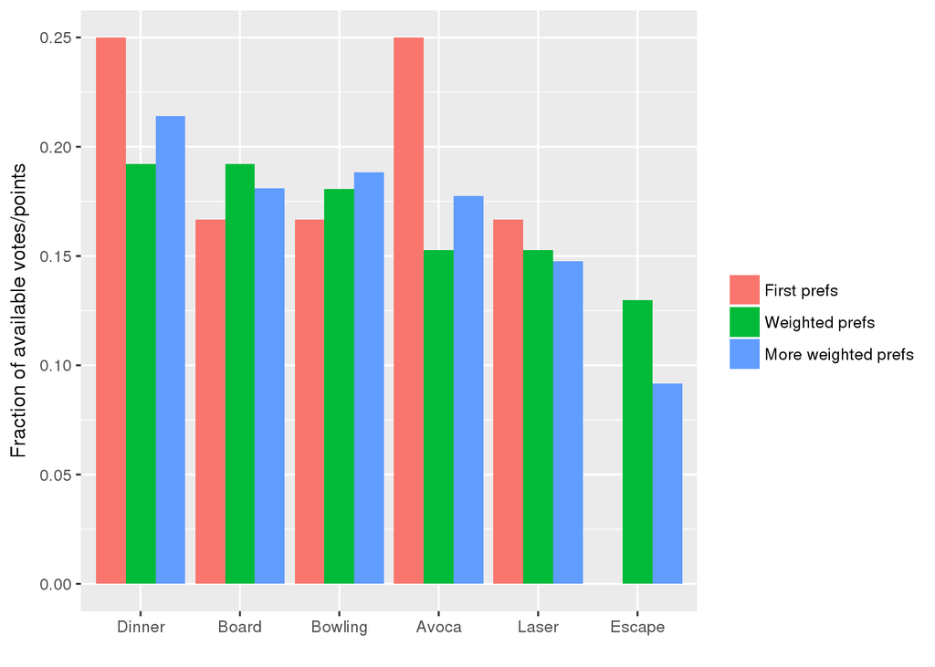

### Transfers

Since the three pathways are quite different, it isn’t very useful to look at the actual transfers from one pathway. Instead I’ve tried to measure the strength of transfers from each candidate to every other candidate, by looking at the ballots in full. This requires some judgement on the weighting of transfers from first preference compared to transfers from further down the ballot, and also of transfers displaced by more than 1 on the ballot (i.e., a transfer from 1 to 3 on the ballot could happen in practice, so is worth something, though not as much as a 1 to 2 transfer). I’ve used a downweighting factor of 2 for both of these. So for example if a particular ballot reads Board 1, Dinner 2, Escape 3, transfers of Board to Dinner, Board to Escape, and Dinner to Escape are registered, and the first is weighted twice as heavily as the second and third. These are combined and averaged to score each pair according to how much of the possible transfer from Candidate to Target was achieved. Complicated, and quite arbitary, but it’s something.

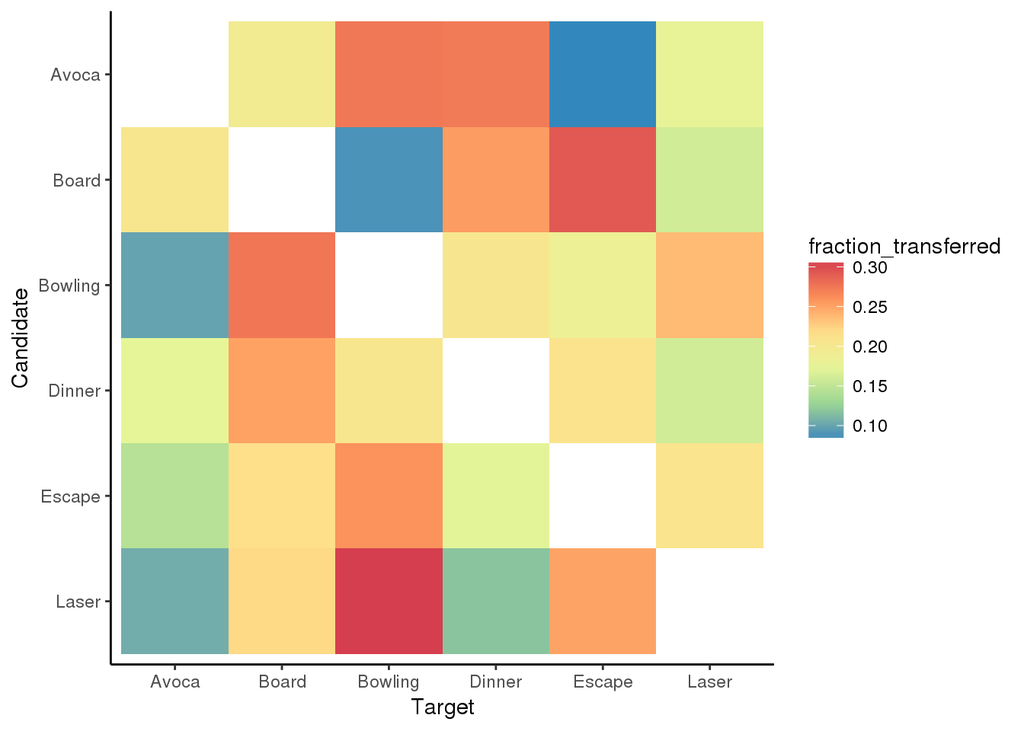

The grid then shows an estimate of the fraction of votes for Candidate that would transfer to Target, over multiple counts where all possible transfer options occur. It does at least highlight some strong relationships, such as Laser-Bowling and Board-Escape, and the generally greater transfers to Board and Bowling than to Avoca. Also note the surprising transfers from Avoca to Bowling being as strong as Avoca to Dinner, as seen in Pathway 2.

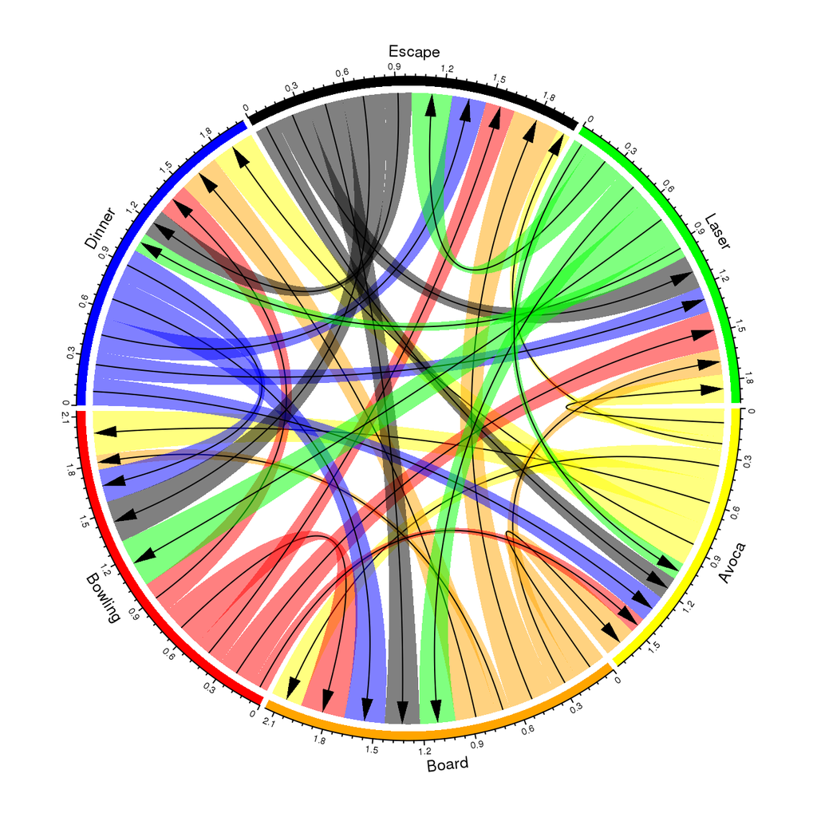

This chord diagram view of the same transfer fractions is perhaps not that useful due to the similarity between most of the fractions, but you can make out e.g. the stronger transfer from Bowling to Laser than from Bowling to Avoca.

### Clustering

For further analysis the 1–6 ballots are converted into measures of preference where a second preference scores half as highly as a first, a third scores half as highly as second, etc (as done in ‘More weighted prefs’ above). Scaling to 100, this gives, e.g.,

```
##    Dinner Bowling   Avoca  Board Escape Laser
## b1 50.000    6.25 100.000  25.00  3.125  12.5
## b2 25.000   50.00   3.125   6.25 12.500 100.0
## b3  3.125   12.50   6.250 100.00 50.000  25.0
```

To compare the voters visually, we can convert from six to two dimensions using PCA, which gives first and second PCs arranged relative to the candidate axes like this:

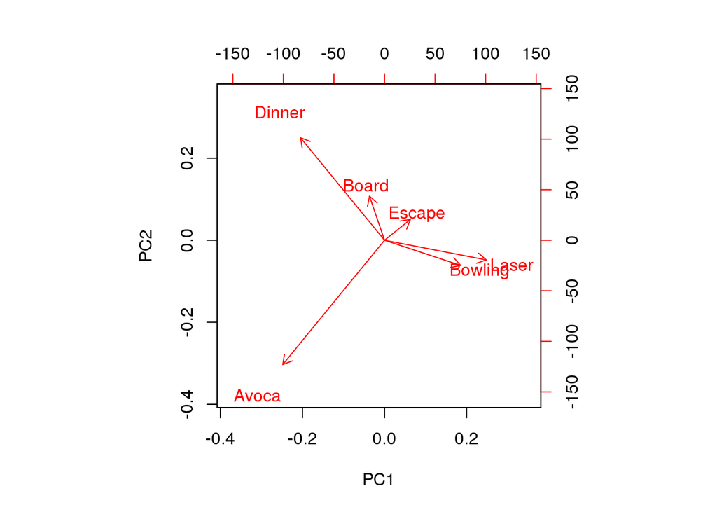

Positive values for PC1 indicate preference for Laser and Bowling, and negative PC1 and PC2 is the Avoca corner. Here then are the ballots plotted on those two principal axes (first preferences in brackets):

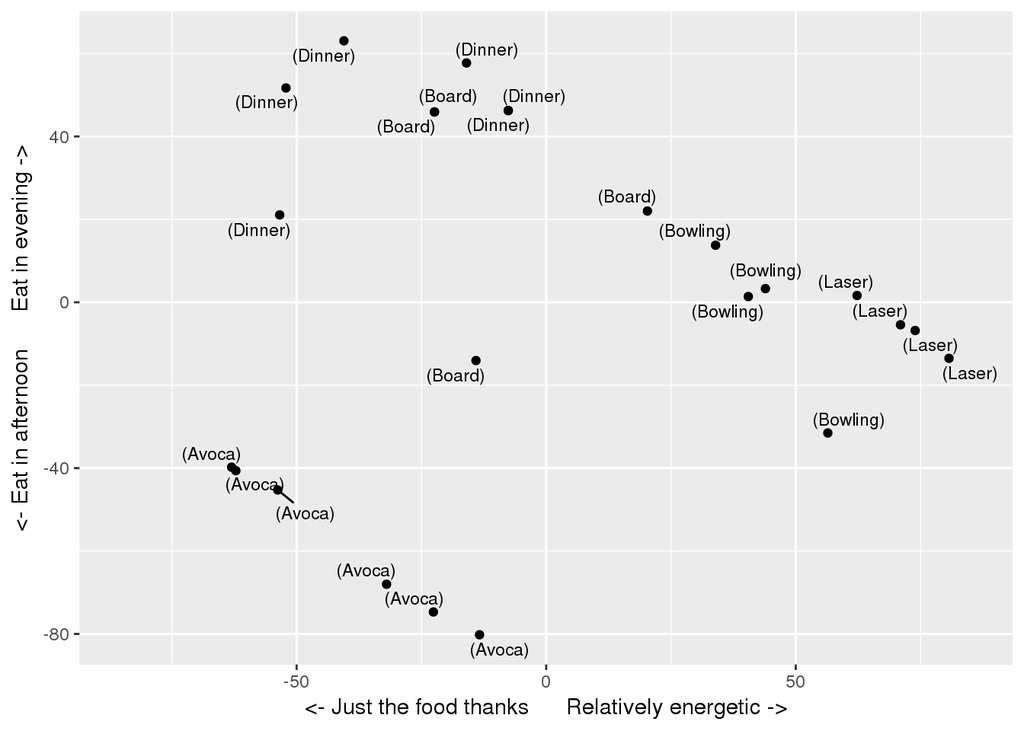

The weighting factor of 2 per preference here pushes the groupings quite strongly towards first preferences, so that the Dinner crew and the Avoca advocates can be easily seen. The rest are ordered on the right by their zealousness of not wanting to sit still.

With two clusters, k-means clustering produces a Laser-Bowling vs Dinner-Avoca split,

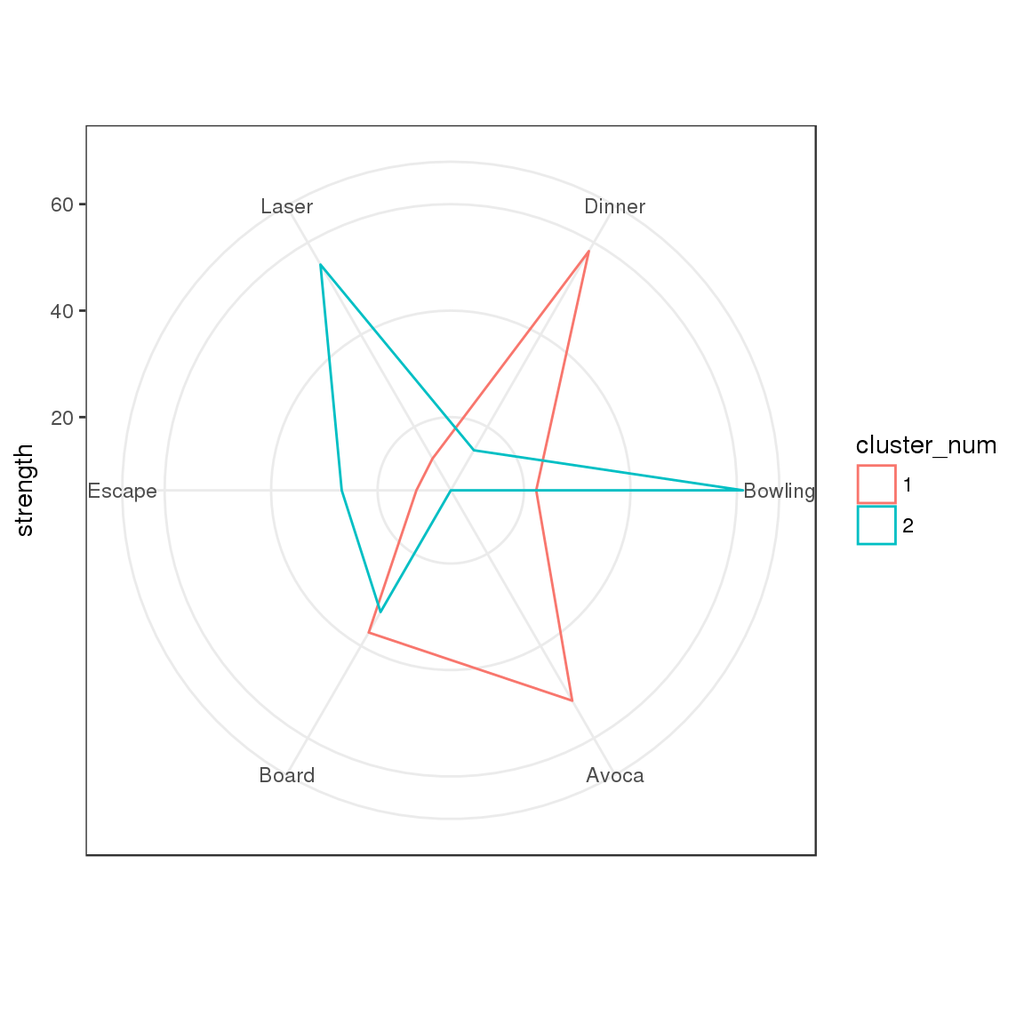

while the three-cluster solution looks more like Avoca vs Dinner-Board vs The Rest:

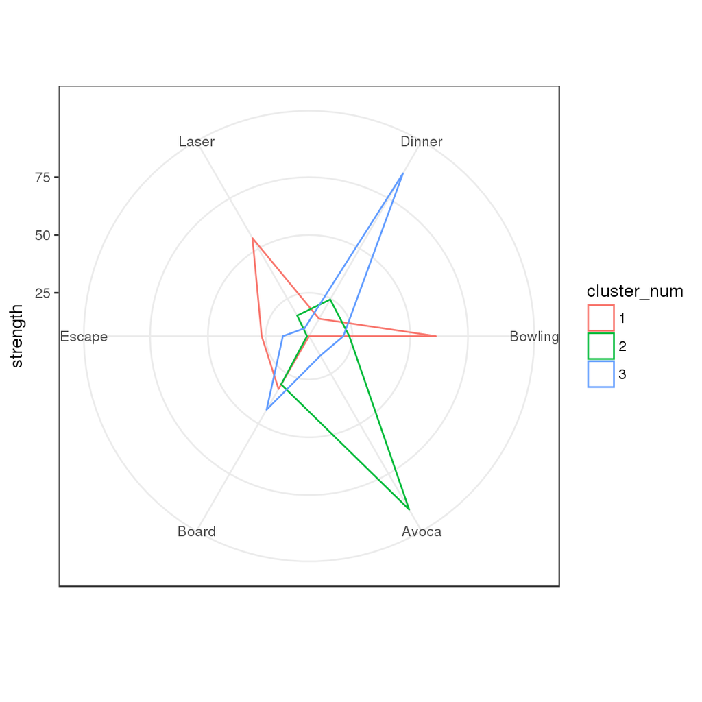

### Two winners

Since it was close and our numbers for dinner are large, we can split up and do two things. One way to decide what the second thing should be is to rerun the STV with two seats available. Unfortunately this does not help us much:

```
##   candidate elected_pct
## 2    Dinner      100.00
## 3     Board       33.88
## 4   Bowling       33.40
## 1     Avoca       32.72
```

In the two-winner case, Dinner is always elected, but Avoca, Bowling, and Board have equal chance (a third) of taking the other seat. The three pathways are similar to above: if Board is eliminated first, Dinner is elected on Round 4 (the quota is 9) and transfers enough to put Avoca in; if Laser goes first, Bowling reaches the quota on Round 4, with nothing to transfer, leaving Dinner ahead of Avoca; if Bowling goes first, Board reaches the quota on Round 4, leaving Dinner ahead of Avoca.

Trying to run separate votes using the clusters from above is problematic due to the arbitrary weighting factor choice of 2, and the small voting groups that result. The two-cluster split above does suggest however that the other thing besides Dinner should not be Avoca, which sits in cluster 1 alongside Dinner.

We could simply go by which two choices would give as many people as possible one of their top preferences:

```
##   option_2 pct_pref_1_2 pct_pref_1_2_3 pct_pref_1_2_3_4
## 1  Bowling         83.3           87.5             95.8
## 2    Avoca         66.7           75.0             83.3
## 3    Board         70.8           83.3             95.8
```

Bowling as the second choice would satisfy most people by this measure, only slightly from Board. Avoca is the more polarising choice, and Dinner/Avoca would not be such a good combination.

So I say, take the second group bowling; [take them bowling](https://www.youtube.com/watch?v=UDB9oCgVHGw).